# Day 4: Pathway Analysis Supplemental Notebook

Jaclyn Taroni

2021-03-26

# Introduction

This notebook is designed to cover questions that came up during the pathway analysis module.

## How to use this notebook

1. Click the `Code` button in the upper right of this page and choose `Download Rmd` to save this notebook (`2021-03-26_muddiest_points.Rmd`) to your computer.
2. Navigate to RStudio server.
3. In your `File` pane, go to `training-modules/pathway-analysis`.
4. Click the `Upload` button in your `File` pane.
5. Click `Choose file` and find this `Rmd` file on your computer.
6. Click `OK`.

# GSEA Visualization

We’ll cover some alternate ways to visualize information returned by `GSEA()`. We’ll also try to introduce you to basic functionality of packages that make plots you may want to make for your own research (e.g., Venn diagrams).

## Set up

### Required libraries

```r
# Package to run GSEA
library(clusterProfiler)
# Package that contains the MSigDB gene sets in tidy format
library(msigdbr)
# Package for creating a heatmap
library(ComplexHeatmap)
# VST
library(DESeq2)
# Pipes
library(magrittr)
# Tile plot
library(ggplot2)
```

We’re also going to use packages called `eulerr` and `VennDiagram` that aren’t installed for all users of our server. If you ever need to install a package, you can use `install.packages()` like so:

```r
install.packages(c("eulerr", "VennDiagram"))
```

(If you’ve downloaded this notebook, you may see some different messages when you run this chunk; that’s okay and expected!)

### Read in differential expression results & expression data

#### Differential expression prep

For this demonstration, we are again going to use the statistics (log2 fold change, specifically) from the neuroblastoma cell line dataset where we compared *MYCN* amplified to non-amplified cell lines.

```r
# Where the DGE results are stored
dge_results_dir <- file.path("..", "RNA-seq", "results", "NB-cell")

# DGE results
dge_results_file <- file.path(
  dge_results_dir,
  "NB-cell_DESeq_amplified_v_nonamplified_results.tsv"
)

# Read in the data
dge_results_df <- readr::read_tsv(dge_results_file)
```

Filter out duplicates by selecting instances of gene symbol with the highest absolute log2 fold change value.

```r
filtered_dge_df <- dge_results_df %>%
  # Sort so that the highest absolute values of the log2 fold change are at the
  # top
  dplyr::arrange(dplyr::desc(abs(log2FoldChange))) %>%
  # Filter out the duplicated rows using `dplyr::distinct()`
  dplyr::distinct(gene_symbol, .keep_all = TRUE)
```

Get the sorted vector we need to supply to GSEA function.

```r
# Vector of log2 fold changes
lfc_vector <- filtered_dge_df %>%
  # Extract a vector of `log2FoldChange` named by `gene_symbol`
  dplyr::pull(log2FoldChange, name = gene_symbol)

# Sort named vector in decreasing order
lfc_vector <- sort(lfc_vector, decreasing = TRUE)
```

#### Transformed RNA-seq data

We’ll use the `SummarizedExperiment` for the NB cell line experiment (e.g., output of `tximeta`) to create a `DESeqDataSet` we can transform. We’re going to use the transformed data to make a heatmap.

```r
# directory with the tximeta processed data
txi_dir <- file.path("..", "RNA-seq", "data", "NB-cell", "txi")
txi_file <- file.path(txi_dir, "NB-cell_tximeta.RDS")
txi <- readr::read_rds(txi_file)
```

Make a `DESeqDataSet` and perform variance stabilizing transformation ahead of our visualization.

```r
ddset <- DESeqDataSet(txi,
                      design = ~ 1)
```

```
using counts and average transcript lengths from tximeta
```

```r
vst_data <- vst(ddset, blind = TRUE)
```

```
using 'avgTxLength' from assays(dds), correcting for library size
```

### Plot output directory

```r
plots_dir <- file.path("plots", "NB-cell")
if (!dir.exists(plots_dir)) {
  dir.create(plots_dir, recursive = TRUE)
}
```

## Perform GSEA

### Gene sets

We’ll use Hallmark gene sets like we did during instruction and we’re working with human data.

```r
hs_hallmarks_df <- msigdbr(species = "Homo sapiens",
                           category = "H")
```

### Run GSEA

Now we’re ready to run GSEA using the same settings we used during instruction.

```r
gsea_results <- GSEA(geneList = lfc_vector,  # ordered ranked gene list
                     minGSSize = 25,  # minimum gene set size
                     maxGSSize = 500,  # maximum gene set set
                     pvalueCutoff = 0.05,
                     pAdjustMethod = "BH",  # correction for multiple hypothesis testing
                     TERM2GENE = dplyr::select(hs_hallmarks_df,
                                               gs_name,
                                               gene_symbol))
```

```
preparing geneSet collections...
GSEA analysis...
There are ties in the preranked stats (0.06% of the list).
The order of those tied genes will be arbitrary, which may produce unexpected results.leading edge analysis...
done...
```

Let’s get the `result` slot into a data frame so we can more easily use `tidyverse` tools on it.

```r
gsea_results_df <- data.frame(gsea_results@result)
colnames(gsea_results_df)
```

```
 [1] "ID"              "Description"     "setSize"         "enrichmentScore" "NES"             "pvalue"
 [7] "p.adjust"        "qvalues"         "rank"            "leading_edge"    "core_enrichment"
```

The `core_enrichment` column contains the genes that are in the leading edge subset of genes for that pathway. **These are the genes that “contribute most to the enrichment result.”** ([GSEA docs](https://www.gsea-msigdb.org/gsea/doc/GSEAUserGuideTEXT.htm#_Gene_Set_Details_1))

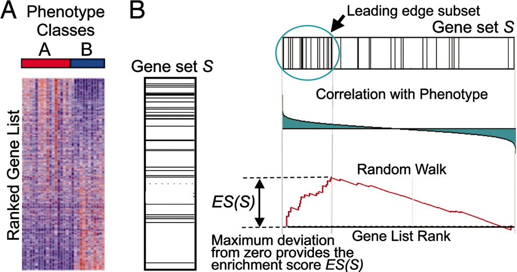

**Figure 1. [Subramanian *et al.* (2005)](https://doi.org/10.1073/pnas.0506580102).**

Let’s look at the *current format* for these leading edge genes.

```r
gsea_results_df %>%
  dplyr::pull(core_enrichment)
```

```
 [1] "SFRP4/VIM/MMP1/P3H1/PLOD1/GPC1/LGALS1/ITGAV/LOXL2/NOTCH2/COL…"
 [2] "CASP8/IFI44L/LATS2/HIF1A/GBP4/NOD1/C1R/RNF213/JAK2/CASP1/MX1…-B/VAMP5/MVP/IFIT1/EPSTI1/MX2/IFITM3/CASP4/CCL2/CD274/IFIH1"
 [3] "NPM1/ODC1/APEX1/NME1/HDAC2/RRP9/PRDX4/FBL/SRPK1/EEF1B2/HNRNP…"
 [4] "CASP8/NUB1/IFI44L/MVB12A/GBP4/CASP1/CSF1/MX1/IFI27/RNF31/B2M…-C/TDRD7/SAMD9L/SAMD9/EPSTI1/IFITM3/IFIH1"
 [5] "TNIP2/PLPP3/EFNA1/BHLHE40/SGK1/RELA/CSF1/DUSP5/IER3/TANK/IL6…"
 [6] "MTHFD2/PPM1D/UNG/NME1/PNN/PRDX4/LBR/MRE11/JPT1/HMGB3/DCTPP1/…"
 [7] "RCE1/CALM3/APOBEC3F/GCA/TIMP1/PCLO/CASP7/KLKB1/CDA/GNAI3/PDG…"
 [8] "EXOC4/CLDN7/ITGB1/TRO/ACTC1/NECTIN4/VAV2/CDH8/THBS3/ARHGEF6/…"
 [9] "APOA1/TIMP1/C8G/BMP1/THBD/KLKB1/MMP2/PDGFB/OLR1/CRIP2/CTSE/L…"
[10] "MEIS1/CDC7/ODC1/LIG3/SLC38A1/LBR/AMD1/JPT1/HMGB3/SLC7A5/DKC1…"
[11] "PLAT/VWA5A/DCBLD2/TOR1AIP2/ADAM17/TFPI/PTGS2/IKZF1/ANGPTL4/A…"
[12] "BHLHE40/SH2B1/GPX3/GJA5/SPTAN1/PICK1/RIT1/RB1/TSC2/FLII/MAPR…"
[13] "PLPP3/LAMC1/BHLHE40/ADGRL2/SLC22A18/RASA2/ATRN/IGF1R/WDR37/ADD3/PIAS3/PTPRM/NR3C1/ANXA2/NOTCH2/COL5A2/INPP4B/TGFBR2/TFPI/TJP1/KCNMA1/PDLIM5/ITGB3/F3/CAV1/ANXA4/PIK3CD/SERPINE1/DAB2/MT1E/MYC"
[14] "PRDX5/SDC3/TPBG/WSB1/KDELR3/EFNA3/BCAN/CSRP2/EFNA1/BHLHE40/T…"
[15] "RAB31/TGFB1/LEFTY2/SPTBN1/SKI/CDK9/ACVR1/TJP1/ENG/FURIN/WWTR1/BCAR3/THBS1/LTBP2/SERPINE1"
[16] "RHOB/CASP8/CASP9/RETSAT/DPYD/ANXA1/GPX3/SPTAN1/PSEN1/RELA/CA…"
```

This could be formatted in a way that is more helpful! Luckily, we can take advantage of the fact that the genes are split up by `/`. And we’ll probably want to split this information up by whether a pathway has a *positive* or *negative* Normalized Enrichment Score (NES).

### Visualizing overlap in leading edge subsets

It can be helpful to understand if the pathways that come up as significant have overlapping genes.

Let’s look at *leading edge genes* for pathways. Again, these are the genes in a pathway that make up the core of the enrichment signal. There are many more significant negative pathways than positive pathways, so comparing the leading edge subsets might be more interesting.

First, let’s use `tidyr::separate_rows()` to get a data frame where one column is the pathway and one column is gene symbols.

```r
# Pathways **down** in amplified cell lines
neg_gene_pathway_df <- gsea_results_df %>%
  # Only rows that have negative NES
  dplyr::filter(NES < 0) %>%
  # Selected columns: the pathway name or ID and leading edge genes
  dplyr::select(ID, core_enrichment) %>%
  # Long format for gene-pathway pairs, splitting on the / that separates
  # genes
  tidyr::separate_rows(core_enrichment, sep = "/") %>%
  # Rename the columns
  dplyr::rename(pathway_id = ID,
                gene = core_enrichment)

neg_gene_pathway_df
```

| pathway_id | gene |
| --- | --- |
| HALLMARK_EPITHELIAL_MESENCHYMAL_TRANSITION | SFRP4 |
| HALLMARK_EPITHELIAL_MESENCHYMAL_TRANSITION | VIM |
| HALLMARK_EPITHELIAL_MESENCHYMAL_TRANSITION | MMP1 |
| HALLMARK_EPITHELIAL_MESENCHYMAL_TRANSITION | P3H1 |
| HALLMARK_EPITHELIAL_MESENCHYMAL_TRANSITION | PLOD1 |
| HALLMARK_EPITHELIAL_MESENCHYMAL_TRANSITION | GPC1 |
| HALLMARK_EPITHELIAL_MESENCHYMAL_TRANSITION | LGALS1 |
| HALLMARK_EPITHELIAL_MESENCHYMAL_TRANSITION | ITGAV |
| HALLMARK_EPITHELIAL_MESENCHYMAL_TRANSITION | LOXL2 |
| HALLMARK_EPITHELIAL_MESENCHYMAL_TRANSITION | NOTCH2 |

[output cut: 652 more lines]

We can use `split` to turn this data frame into a list where each element of the list is a vector of gene symbols in the leading edge subset and is named for the pathway.

```r
neg_leading_list <- split(neg_gene_pathway_df$gene,
                          neg_gene_pathway_df$pathway_id)
```

Now we can examine the leading edge subset of genes for a pathway using the pathway name (or we could use `dplyr::filter()` on the data frame above, if we prefer).

```r
neg_leading_list[["HALLMARK_APOPTOSIS"]]
```

```
 [1] "RHOB"      "CASP8"     "CASP9"     "RETSAT"    "DPYD"      "ANXA1"     "GPX3"      "SPTAN1"    "PSEN1"
[10] "RELA"      "CASP1"     "CYLD"      "IER3"      "BCAP31"    "HSPB1"     "TXNIP"     "BCL2L10"   "SQSTM1"
[19] "AIFM3"     "BIK"       "CCNA1"     "PLAT"      "LMNA"      "TAP1"      "SAT1"      "CFLAR"     "ERBB3"
[28] "CDKN1A"    "CASP6"     "DCN"       "CD44"      "PPP2R5B"   "LGALS3"    "PEA15"     "CAV1"      "TNFRSF12A"
[37] "GSN"       "EMP1"      "IGFBP6"    "IFITM3"    "CASP4"     "IL1B"      "KRT18"
```

#### Jaccard index

The [Jaccard index](https://en.wikipedia.org/wiki/Jaccard_index) (also called Jaccard similarity) is a measure of similarity between two sets. The values are bounded between 0 and 1, where 0 indicates no overlap and 1 indicates perfect overlap. We can write a custom function to calculate the Jaccard index for two character vectors.

```r
calculate_jaccard <- function(x, y) {
  # Calculate Jaccard index for two character vectors, x and y, which is the
  # size of the intersection divided by the size of the union
  length(intersect(x, y)) / length(union(x, y))
}
```

Let’s calculate the Jaccard index between each pair of pathways’ leading edge subsets. Pairs of pathways with a higher Jaccard index have more similar leading edge subsets. `combn()` is a function that will generate all combinations of the elements of `x` (the first argument) taken `m` (the second argument) at a time; we want it to return a *list* we can use with `purrr` so we use `simplify = FALSE`.

```r
neg_leading_jaccard <-
  # Get a list that is comprised of each pair of pathways
  combn(neg_leading_list, 2, simplify = FALSE) %>%
  # Calculate the Jaccard index between the two vector of leading edge subsets
  purrr::map(~ calculate_jaccard(.x[[1]], .x[[2]])) %>%
  # Return a numeric vector, not a list
  purrr::flatten_dbl()
```

Make into a data frame for plotting with `ggplot2`, where each row will contain a pairwise Jaccard value.

```r
# We'll want to add back in the names of the pathways!
neg_jaccard_df <-
  # Get the combination of pathway names
  data.frame(t(combn(names(neg_leading_list), 2))) %>%
  # Add Jaccard index
  dplyr::mutate(jaccard_index = neg_leading_jaccard,
                # Replace underscores with spaces in pathway 1 names
                X1 = stringr::str_replace_all(X1, "_", " "),
                # Replace underscores with spaces in pathway 2 names
                X2 = stringr::str_replace_all(X2, "_", " "))

neg_jaccard_df
```

| X1 | X2 | jaccard_index |
| --- | --- | --- |
| HALLMARK APICAL JUNCTION | HALLMARK APOPTOSIS | 0.000000000 |
| HALLMARK APICAL JUNCTION | HALLMARK COAGULATION | 0.034188034 |
| HALLMARK APICAL JUNCTION | HALLMARK COMPLEMENT | 0.036496350 |
| HALLMARK APICAL JUNCTION | HALLMARK EPITHELIAL MESENCHYMAL TRANSITION | 0.023622047 |
| HALLMARK APICAL JUNCTION | HALLMARK HYPOXIA | 0.016260163 |
| HALLMARK APICAL JUNCTION | HALLMARK INTERFERON ALPHA RESPONSE | 0.000000000 |
| HALLMARK APICAL JUNCTION | HALLMARK INTERFERON GAMMA RESPONSE | 0.013986014 |
| HALLMARK APICAL JUNCTION | HALLMARK KRAS SIGNALING UP | 0.018691589 |
| HALLMARK APICAL JUNCTION | HALLMARK MYOGENESIS | 0.016949153 |
| HALLMARK APICAL JUNCTION | HALLMARK TGF BETA SIGNALING | 0.011764706 |

[output cut: 68 more lines]

Now we’ll plot the pairwise Jaccard index values using `geom_tile()`. One thing to note is that text that looks squished in display in a notebook might be a good size for a plot saved to file (or vice versa depending on your set up).

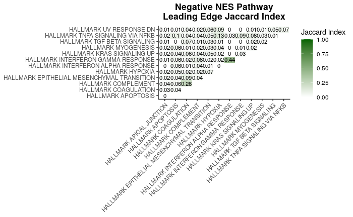

```r
neg_jaccard_df %>%
  # Make a tile plot of the pathway similarity values
  ggplot(aes(x = X1,
             y = X2,
             fill = jaccard_index)) +
  geom_tile() +
  # Add text to the tiles that indicates the Jaccard index values
  geom_text(aes(x = X1, y = X2, label = round(jaccard_index, 2)),
            color = "black", size = 3) +
  # White-dark green gradient, bounded at 0 and 1 like the metric we are using
  scale_fill_gradientn(
    colors = c("#FFFFFF", "#006400"),
    limits = c(0, 1),
    name = "Jaccard index"  # What to call it in the legend
  ) +
  # Built in theme
  theme_classic() +
  # Remove the x and y axis labels
  labs(x = NULL,
       y = NULL,
       # Add a title that's broken up over two lines
       title = "Negative NES Pathway\nLeading Edge Jaccard Index") +
  # Rotate x-axis text 45 degrees
  theme(axis.text.x = element_text(hjust = 1, angle = 45),
        # Center the plot title and make it bold
        plot.title = element_text(face = "bold", hjust = 0.5))
```

Save this plot with `ggsave()`.

```r
ggsave(file.path(plots_dir, "negative_NES_leading_edge_jaccard.png"),
       plot = last_plot(),
       width = 11,
       height = 7)
```

If we were not particularly concerned about “mixing” the pathways with positive or negative scores, we could use `enrichplot::pairwise_termsim()` with the `method = "JC"` argument to calculate the Jaccard similarity instead. From the documentation for this function, it’s not totally clear if this includes the core enrichment genes *only*.

```r
# Add a matrix of Jaccard similarity values to the @termsim slot of gsea_results
gsea_results <- enrichplot::pairwise_termsim(gsea_results, method = "JC")

# Let's take a look at the "top left" corner of that matrix
gsea_results@termsim[1:5, 1:5]
```

```
                                           HALLMARK_EPITHELIAL_MESENCHYMAL_TRANSITION
HALLMARK_EPITHELIAL_MESENCHYMAL_TRANSITION                                         NA
HALLMARK_INTERFERON_GAMMA_RESPONSE                                                 NA
HALLMARK_MYC_TARGETS_V1                                                            NA
HALLMARK_INTERFERON_ALPHA_RESPONSE                                                 NA
HALLMARK_TNFA_SIGNALING_VIA_NFKB                                                   NA
                                           HALLMARK_INTERFERON_GAMMA_RESPONSE HALLMARK_MYC_TARGETS_V1
HALLMARK_EPITHELIAL_MESENCHYMAL_TRANSITION                         0.01526718                       0
HALLMARK_INTERFERON_GAMMA_RESPONSE                                         NA                       0
HALLMARK_MYC_TARGETS_V1                                                    NA                      NA
HALLMARK_INTERFERON_ALPHA_RESPONSE                                         NA                      NA
HALLMARK_TNFA_SIGNALING_VIA_NFKB                                           NA                      NA
                                           HALLMARK_INTERFERON_ALPHA_RESPONSE HALLMARK_TNFA_SIGNALING_VIA_NFKB
HALLMARK_EPITHELIAL_MESENCHYMAL_TRANSITION                        0.009433962                       0.05357143
HALLMARK_INTERFERON_GAMMA_RESPONSE                                0.435294118                       0.09016393
HALLMARK_MYC_TARGETS_V1                                           0.000000000                       0.00000000
HALLMARK_INTERFERON_ALPHA_RESPONSE                                         NA                       0.02884615
HALLMARK_TNFA_SIGNALING_VIA_NFKB                                           NA                               NA
```

#### Venn diagram

Let’s make a Venn diagram examining the overlap between leading edge subsets for pathways that have significant positive NES values.

```r
positive_nes_df <- gsea_results_df %>%
  dplyr::filter(NES > 0) %>%
  dplyr::select(ID, core_enrichment)
```

The `eulerr` package, which we will use for visualization, can use a list to calculate overlaps. We’ll show you a different way to get a list where each element is a vector that contains the gene IDs for the leading edge subset. (Before we used `tidyr::separate_rows()` and then `split()`.)

```r
pos_leading_list <- positive_nes_df %>%
  # Get a vector of the core enrichment genes
  dplyr::pull(core_enrichment) %>%
  # Split into individual genes using / as the pattern for splitting
  stringr::str_split(., pattern = "/") %>%
  # Set the names of the list as the pathway names
  purrr::set_names(positive_nes_df %>% dplyr::pull(ID))
```

Now for a Venn diagram!

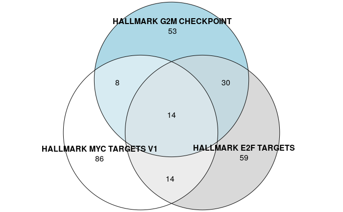

```r
pos_venn <- plot(eulerr::venn(pos_leading_list),
                 # Replace the underscores with spaces in the labels
                 labels = stringr::str_replace_all(names(pos_leading_list),
                                                   "_", " "))
pos_venn
```

To save this plot, we need to use `png()` and `dev.off()` because it is not a `ggplot`.

```r
png(file.path(plots_dir, "positive_NES_leading_edge_venn.png"),
    width = 7,
    height = 7,
    units = "in",
    res = 300)
pos_venn
dev.off()
```

To get more information about the identity of the genes that comprise the overlaps, we can use `calculate.overlap()` from the `VennDiagram` package.

```r
pos_overlap_list <- VennDiagram::calculate.overlap(pos_leading_list)
head(pos_overlap_list, n = 2)
```

```
$a5
 [1] "MAD2L1"  "SYNCRIP" "MCM5"    "SRSF1"   "NOLC1"   "MCM2"    "TRA2B"   "HNRNPD"  "MCM6"    "KPNA2"
[11] "CDK4"    "XPO1"    "SRSF2"   "GSPT1"

$a2
 [1] "NME1"   "PRDX4"  "MCM4"   "RANBP1" "NOP56"  "XRCC6"  "RAN"    "MCM7"   "USP1"   "PA2G4"  "PCNA"   "NAP1L1"
[13] "CTPS1"  "DEK"
```

### Heatmap of transformed RNA-seq data for leading edge genes

One of the pathways with a significant positive NES is “HALLMARK E2F TARGETS.” Let’s look at the GSEA plot for this pathway.

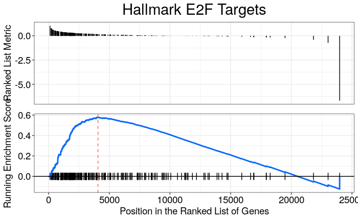

```r
enrichplot::gseaplot(gsea_results,
                     geneSetID = "HALLMARK_E2F_TARGETS",
                     title = "Hallmark E2F Targets",
                     color.line = "#0066FF")
```

This is a `ggplot` “under the hood” so we can save this with `ggsave()`, too.

```r
ggsave(file.path(plots_dir, "E2F_targets_GSEA.png"),
       plot = last_plot())
```

Sometimes folks will plot expression values of individual genes using GSEA results as a guide. Below, we’ll make a heatmap of the transformed values for the genes that are in the leading edge for the “E2F TARGETS” Hallmark gene set. First, let’s get the transformed values into matrix form.

```r
# Extract the matrix of VST RNA-seq data
transformed_rnaseq_mat <- assay(vst_data)
```

We’ll only display genes that are in the Hallmark E2F Targets leading edge subset, which we can access by name with `$` from our list of leading edge genes for pathways with significant, positive NES (`pos_leading_list`). But, there’s a problem: these are gene symbols and the row names of the transformed RNA-seq matrix are Ensembl gene IDs! We used the `filtered_dge_df` data frame of statistics for our GSEA step itself and this data frame has both Ensembl gene IDs and gene symbols. So we can use that to grab the Ensembl gene IDs that are in the leading edge for the Hallmark E2F Targets pathway.

```r
e2f_ensg_ids <- filtered_dge_df %>%
  # Rows with gene symbols that are in the leading edge for E2F targets
  dplyr::filter(gene_symbol %in% pos_leading_list$HALLMARK_E2F_TARGETS) %>%
  # Get a vector of Ensembl gene IDs in that row where the names of the vector
  # are the corresponding gene symbol
  dplyr::pull(gene_id, name = gene_symbol)
```

Now subset the transformed RNA-seq matrix to the E2F targets leading edge genes only and z-score for display.

```r
# Use the Ensembl gene IDs to pull out the genes (rows) in the leading edge
e2f_mat <- transformed_rnaseq_mat[e2f_ensg_ids, ]
# "Convert" rownames to gene symbols using the names of the vector that contains
# the Ensembl gene identifiers. These will necessarily be in the same order.
rownames(e2f_mat) <- names(e2f_ensg_ids)
# Calculate z-scores for display
e2f_mat <- (e2f_mat - rowMeans(e2f_mat)) / matrixStats::rowSds(e2f_mat)
```

We probably want to include the amplified, non-amplified status information as heatmap annotation. Let’s set that up in the next chunk.

```r
# We can snag the sample IDs and the status information from our DESeqTransform
# object
sample_annotation_df <- data.frame(
  sample_id = vst_data$names,
  status = vst_data$status
) %>%
  # But ComplexHeatmap wants the sample IDs as rownames
  tibble::column_to_rownames("sample_id")

# The Okabe Ito palette is recommended for those with color vision deficiencies
status_colors <- palette.colors(palette = "Okabe-Ito")[2:3]
sample_annotation_colors <- list(
  status = c(
    "Amplified" = status_colors[[1]],
    "Nonamplified" = status_colors[[2]]
  )
)

# Now to make the actual object we pass to Heatmap
column_annotation <- HeatmapAnnotation(
  df = sample_annotation_df,
  col = sample_annotation_colors,
  annotation_label = c("MYCN Status")
)
```

One thing to remember is that genes that contribute to an enrichment score won’t *necessarily* be significantly differentially expressed. So let’s add a *row annotation* that includes the log2 fold change information because log2 fold change is how we rank genes for GSEA. We need to start by getting a data frame for the Hallmark E2F Target leading edge subset that has the log2 fold change as a column and the gene identifiers (here gene symbols) as the rownames.

```r
row_annotation_df <- filtered_dge_df %>%
  # Rows with gene symbols that are in the leading edge for E2F targets
  dplyr::filter(gene_symbol %in% pos_leading_list$HALLMARK_E2F_TARGETS) %>%
  # Only need the gene symbol and LFC column
  dplyr::select(gene_symbol, log2FoldChange) %>%
  # Gene identifiers, which are our row identifiers, will need to be row names
  tibble::column_to_rownames("gene_symbol")
```

Because we’re looking at the leading edge genes for a pathway with a positive NES, let’s create a sequential palette where values around zero will be represented in white and the values that are most highly positive are a darker color. Here we’ll use navy blue, which is a built in color in R.

```r
# Color palette we'll use for LFC
col_fun <- circlize::colorRamp2(c(min(row_annotation_df$log2FoldChange),
                                  max(row_annotation_df$log2FoldChange)),
                                c("white", "navy"))

# To make a row annotation object, we use rowAnnotation()
row_annotation <- rowAnnotation(
  df = row_annotation_df,
  col = list(log2FoldChange = col_fun),
  annotation_label = c("log2 fold change")
)
```

`ComplexHeatmap` allows us to split up rows or columns by a categorical variable. Here we’d use status, but let’s double check that our samples are in the same order in `sample_annotation_df` and the expression matrix.

```r
all.equal(colnames(e2f_mat), rownames(sample_annotation_df))
```

```
[1] TRUE
```

Okay, let’s make our heatmap!

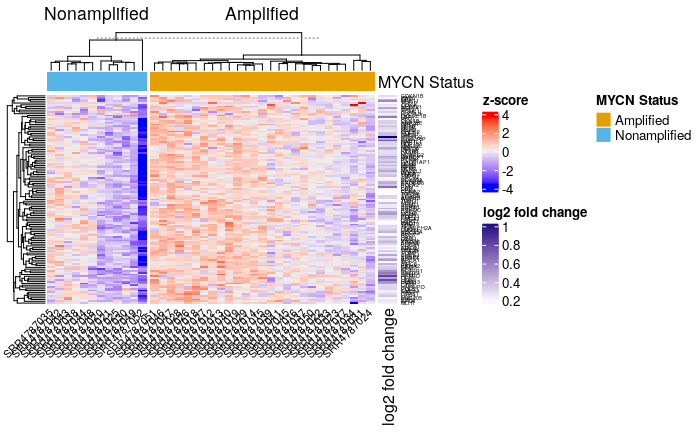

```r
ComplexHeatmap::Heatmap(e2f_mat,
                        # Add annotation bars to the top of the heatmap
                        top_annotation = column_annotation,
                        # Add annotation to the rows
                        right_annotation = row_annotation,
                        # Split the heatmap based on MYCN amplification
                        # status
                        column_split = sample_annotation_df$status,
                        # This will be used as the label for the color bar
                        # of the cells of the heatmap itself
                        name = "z-score",
                        # Make the gene symbols smaller
                        row_names_gp = gpar(fontsize = 4),
                        # Make the sample names smaller
                        column_names_gp = gpar(fontsize = 8),
                        # Display sample names on a 45 degree angle
                        column_names_rot = 45)
```

Let’s save this to a file.

```r
png(file.path(plots_dir, "E2F_targets_leading_edge_heatmap.png"),
    width = 11,
    height = 7,
    units = "in",
    res = 300)
ComplexHeatmap::Heatmap(e2f_mat,
                        # Add annotation bars to the top of the heatmap
                        top_annotation = column_annotation,
                        # Add annotation to the rows
                        right_annotation = row_annotation,
                        # Split the heatmap based on MYCN amplification
                        # status
                        column_split = sample_annotation_df$status,
                        # This will be used as the label for the color bar
                        # of the cells of the heatmap itself
                        name = "z-score",
                        # Make the gene symbols smaller
                        row_names_gp = gpar(fontsize = 4),
                        # Make the sample names smaller
                        column_names_gp = gpar(fontsize = 8),
                        # Display sample names on a 45 degree angle
                        column_names_rot = 45,
                        # Higher resolution for output (be careful with PDF output!)
                        use_raster = FALSE)
# Shut down current graphics device
dev.off()
```

## Parting thoughts

We hope a take home message of this notebook is that R has a rich ecosystem of packages that allow you to make publication ready plots. It’s also usually possible to accomplish something in R multiple ways. [`enrichplot`](https://bioconductor.org/packages/release/bioc/html/enrichplot.html) is capable of producing [many different kinds of visualizations](http://yulab-smu.top/clusterProfiler-book/chapter12.html) (sometimes the documentation can be sparse). Often if we can figure out how to extract data out of specialized objects and wrangle it, we have more control over what kinds of calculations we can perform and can take full advantage of plot customization in `ggplot2`. These data wrangling steps can take a lot of trial and error, even for experienced R programmers like your instructors, so don’t be discouraged and keep practicing!